# Tema 3.3 - Strings, Fechas y Factores

Roi Naveiro

2022-12-18

# Data Wrangling

**Objetivo**: dejar los datos listos para su posterior **exploración** y **modelización**

Convertir **datos crudos** en **datos procesados**

**Datos crudos**

- Los datos tal cual aparecen en la fuente de origen
- No han sufrido ninguna manipulación

**Datos procesados**

- Cada variable es una columna
- Cada observación una fila
- Cada unidad observacional es una celda
- Datos más complejos, en varias tablas interconectadas

# Data Wrangling

- Importación de los datos
- Organización de los datos
- Transformación de los datos

# Transformación de datos

- Strings
- Factores
- Fechas y horas

# Strings

- Veremos lo básico de manipulación de strings
- Datos en formato texto

```r
"Esto es un string"
```

```
## [1] "Esto es un string"
```

```r
c("una", "dos y tres")
```

```
## [1] "una"        "dos y tres"
```

- Expresiones regulares (regexps): permiten identificar patrones en texto
- Usaremos `stringr` de tidyverse para manipular strings
- Todas sus funciones empiezan con `str_`

# Strings: longitud

Podemos calcular la longitud de una string usando `str_length()`

```r
str_length("Hola")
```

```
## [1] 4
```

Las operaciones están vectorizadas

```r
str_length( c("Hola", "Adiós") )
```

```
## [1] 4 5
```

**Pregunta:** ¿Qué pasa si hay espacios?

# Strings: combinación

Combinamos strings con `str_c`

```r
str_c("Ma", "drid")
```

```
## [1] "Madrid"
```

```r
str_c("Un", "dos", sep=",")
```

```
## [1] "Un,dos"
```

**Pregunta**: ¿Cómo combinarías dos strings con una coma seguida de un espacio?

# Strings: combinación

También vectorizado!

```r
str_c("prefijo-", c("X", "Y", "Z"), "-sufijo")
```

```
## [1] "prefijo-X-sufijo" "prefijo-Y-sufijo" "prefijo-Z-sufijo"
```

Para colapsar un texto largo en una única string

```r
str_c(c("En", "un", "lugar", "de", "la", "Mancha"), collapse = " ")
```

```
## [1] "En un lugar de la Mancha"
```

# Strings: subsetting

Para extraer partes de una string usamos `str_sub`

```r
x <- c("Liberty", "La Nuit")
str_sub(x, 1, 3)
```

```
## [1] "Lib" "La "
```

```r
# Con números negativos empieza desde el final
str_sub(x, -3, -1)
```

```
## [1] "rty" "uit"
```

# Strings: cosas útiles

```r
x <- c("Liberty", "La nuit")
str_to_lower(x)
```

```
## [1] "liberty" "la nuit"
```

```r
str_to_upper(x)
```

```
## [1] "LIBERTY" "LA NUIT"
```

```r
str_to_title(x)
```

```
## [1] "Liberty" "La Nuit"
```

# Strings: expresiones regulares

Permiten describir patrones en strings. Se pueden hacer varias cosas con los patrones

- Determinar que strings cumplen el patrón.
- Determinar en qué posición aparece el patrón
- Extraer el patrón
- Reemplazarlo

E.g. patrón “contiene ES seguido de dos números”

```r
x1 <- "ES49"
x2 <- "Mi número de cuenta es ES35 30..."
x3 <- "Resido en España (ES)"
```

# Strings: expresiones regulares

Vamos aprender a jugar con patrones muy sencillos. Primero, coincidencia exacta (ojo mayúsculas y minúsculas!)

```r
x <- c("Cats", "Uñas Chung Lee", "Capital")
str_view(x, "Le")
```

[interactive chart not shown]

**Pregunta**: diferencia entre `str_view` y `str_view_all`

# Strings: expresiones regulares

Para identificar cualquier caracter usamos `.`

```r
x <- c("Cats", "Uñas Chung Lee", "Capital")
str_view(x, ".a.")
```

[interactive chart not shown]

# Strings: expresiones regulares

Empieza por `^` y termina por `$`

```r
x <- c("Cats", "Uñas Chung Lee", "Capital")
str_view(x, "^C")
```

[interactive chart not shown]

```r
str_view(x, "l$")
```

[interactive chart not shown]

# Strings: expresiones regulares

`\d`: cualquie dígito `\s`: espacio en blanco `[abc]`: a, b, o c.

```r
x = c("B12", "Eslava", "Ocho y Medio")
str_view_all(x, "\\d")
```

[interactive chart not shown]

OJO

```r
writeLines("\\d")
```

```
## \d
```

# Strings: expresiones regulares

```r
x = c("ES12", "Mi cuenta es ES46", "Resido en España (ES)")
str_view(x, "ES\\d\\d")
```

[interactive chart not shown]

# Strings: expresiones regulares

**Ejercicio**: Detecta las autovías correctas

```r
x <- c("A1", "A12", "A14", "A6", "EA5", "A3", "F2")
```

# Strings: detectar patrones

Con esto estamos preparados para detectar patrones

```r
x = c("ES12", "Mi cuenta es ES46", "Resido en España (ES)")
str_detect(x, "ES\\d\\d")
```

```
## [1]  TRUE  TRUE FALSE
```

Uso común, seleccionar los elementos que cumplen el patrón

```r
words[str_detect(words, "x$")]
```

```
## [1] "box" "sex" "six" "tax"
```

# Strings: detectar patrones

También con dataframes

```r
df <- tibble(
  word = words,
  i = seq_along(word)
)
df %>%
  filter(str_detect(word, "x$"))
```

```
## # A tibble: 4 × 2
##   word      i
##   <chr> <int>
## 1 box     108
## 2 sex     747
## 3 six     772
## 4 tax     841
```

# Strings: contar patrones

¿Cuántas veces ocurre el patrón?

```r
x <- c("apple", "banana", "pear")
str_count(x, "a")
```

```
## [1] 1 3 1
```

**Ejercicio**: calcula la media de vocales por palabra en `words`.

# Strings: contar patrones

Se usa mucho con mutate

```r
df %>%
  mutate(
    vocales = str_count(word, "[aeiou]"),
  )
```

```
## # A tibble: 980 × 3
##    word         i vocales
##    <chr>    <int>   <int>
##  1 a            1       1
##  2 able         2       2
##  3 about        3       3
##  4 absolute     4       4
##  5 accept       5       2
##  6 account      6       3
##  7 achieve      7       4
##  8 across       8       2
##  9 act          9       1
## 10 active      10       3
## # … with 970 more rows
```

# Factores

- Para trabajar con variables categóricas con número fijo de valores
- Trabajaremos con `forcats` de tiduverse
- Crear factores

# Factores: creación

```r
x1 <- c("Dec", "Apr", "Jan", "Mar")
```

Usar una string para almacenar esta variable tiene dos problemas

- Los valores son fijos y nada previene de errores

```r
x1 <- c("Dec", "Apr", "Jan", "Mer")
```

- No ordena de manera útil

```r
sort(x1)
```

```
## [1] "Apr" "Dec" "Jan" "Mer"
```

# Factores: creación

Esto se arregla creando un factor

```r
month_levels <- c(
  "Jan", "Feb", "Mar", "Apr", "May", "Jun",
  "Jul", "Aug", "Sep", "Oct", "Nov", "Dec"
)
y1 <- factor(x1, levels = month_levels)
sort(y1)
```

```
## [1] Jan Apr Dec
## Levels: Jan Feb Mar Apr May Jun Jul Aug Sep Oct Nov Dec
```

# Factores: creación

Con pipes

```r
f2 <- x1 %>% factor(levels = month_levels)
f2
```

```
## [1] Dec  Apr  Jan  <NA>
## Levels: Jan Feb Mar Apr May Jun Jul Aug Sep Oct Nov Dec
```

# Factores

Trabajaremos con los datos `gss_cat`

```r
glimpse(gss_cat)
```

```
## Rows: 21,483
## Columns: 9
## $ year    <int> 2000, 2000, 2000, 2000, 2000, 2000, 2000, 2000, 2000, 2000, 20…
## $ marital <fct> Never married, Divorced, Widowed, Never married, Divorced, Mar…
## $ age     <int> 26, 48, 67, 39, 25, 25, 36, 44, 44, 47, 53, 52, 52, 51, 52, 40…
## $ race    <fct> White, White, White, White, White, White, White, White, White,…
## $ rincome <fct> $8000 to 9999, $8000 to 9999, Not applicable, Not applicable, …
## $ partyid <fct> "Ind,near rep", "Not str republican", "Independent", "Ind,near…
## $ relig   <fct> Protestant, Protestant, Protestant, Orthodox-christian, None, …
## $ denom   <fct> "Southern baptist", "Baptist-dk which", "No denomination", "No…
## $ tvhours <int> 12, NA, 2, 4, 1, NA, 3, NA, 0, 3, 2, NA, 1, NA, 1, 7, NA, 3, 3…
```

# Factores

**Pregunta**: ¿Cómo identificarías los niveles posibles de la variable `race`?

–

```r
gss_cat %>% count(race)
```

```
## # A tibble: 3 × 2
##   race      n
##   <fct> <int>
## 1 Other  1959
## 2 Black  3129
## 3 White 16395
```

# Factores

- Reordenar niveles
- Modificar niveles

# Factores - Reordenar niveles

Con `fct_reorder()`. Toma tres argumentos

- `f`, el factor que queremos reordenar
- `x`, vector numérico para ordenar
- Opcionalmente, `fun`, en caso de que haya varios valores de `x` para la misma `f`. (Por defecto, `fun` es la mediana)

# Factores - Reordenar niveles

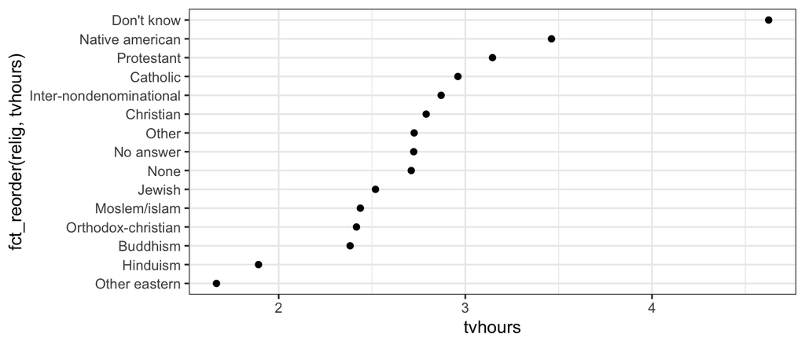

```r
gss_cat %>%
  group_by(relig) %>%
  summarise(tvhours = mean(tvhours, na.rm = TRUE)) %>%
  ggplot(aes(tvhours, fct_reorder(relig, tvhours))) +
    geom_point() + theme_bw()
```

# Factores - Reordenar niveles

Dos opciones

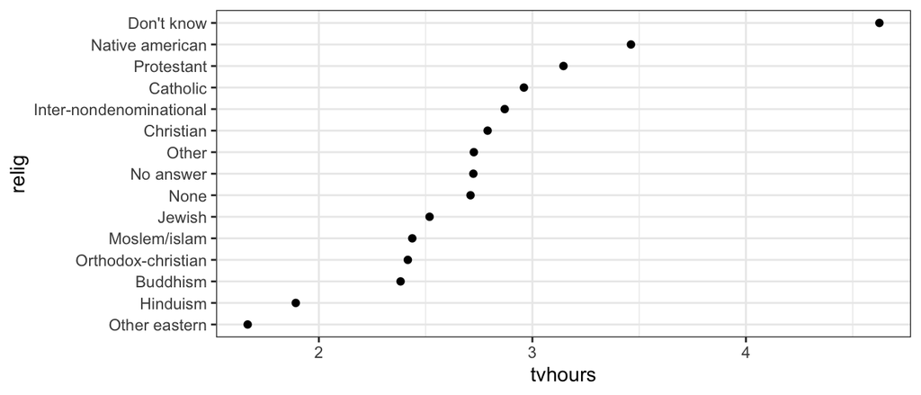

```r
gss_cat %>%
  group_by(relig) %>%
  summarise(tvhours = mean(tvhours, na.rm = TRUE)) %>%
  mutate (relig = fct_reorder(relig, tvhours)) %>%
  ggplot(aes(tvhours, relig)) +
    geom_point() + theme_bw()
```

# Factores - Reordenar niveles

Dos opciones

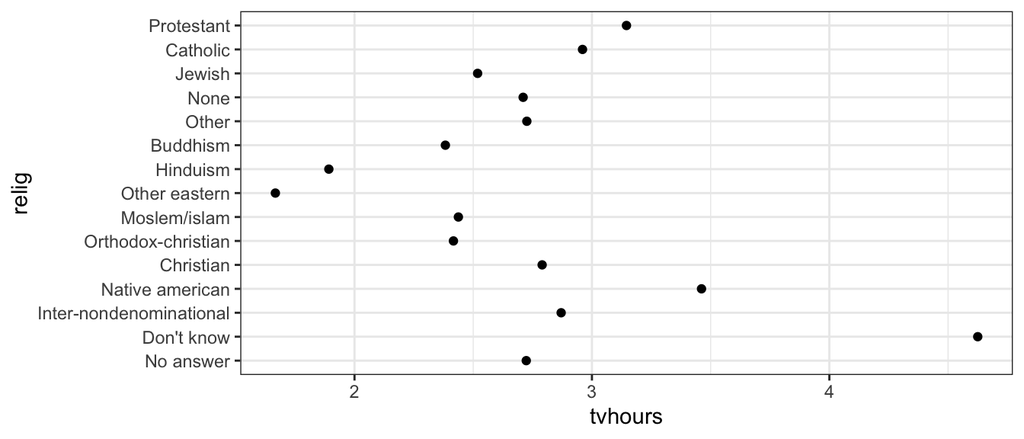

```r
relig_summary <- gss_cat %>%
  group_by(relig) %>%
  summarise(
    age = mean(age, na.rm = TRUE),
    tvhours = mean(tvhours, na.rm = TRUE),
    n = n()
  )
ggplot(relig_summary, aes(tvhours, relig)) + geom_point() + theme_bw()
```

# Factores - Modificar niveles

Usamos `fct_recode()`

```r
gss_cat %>% count(partyid)
```

```
## # A tibble: 10 × 2
##    partyid                n
##    <fct>              <int>
##  1 No answer            154
##  2 Don't know             1
##  3 Other party          393
##  4 Strong republican   2314
##  5 Not str republican  3032
##  6 Ind,near rep        1791
##  7 Independent         4119
##  8 Ind,near dem        2499
##  9 Not str democrat    3690
## 10 Strong democrat     3490
```

# Factores - Modificar niveles

```r
gss_cat %>%
  mutate(partyid = fct_recode(partyid,
    "Republican, strong"    = "Strong republican",
    "Republican, weak"      = "Not str republican",
    "Independent, near rep" = "Ind,near rep",
    "Independent, near dem" = "Ind,near dem",
    "Democrat, weak"        = "Not str democrat",
    "Democrat, strong"      = "Strong democrat"
  )) %>%
  count(partyid)
```

```
## # A tibble: 10 × 2
##    partyid                   n
##    <fct>                 <int>
##  1 No answer               154
##  2 Don't know                1
##  3 Other party             393
##  4 Republican, strong     2314
##  5 Republican, weak       3032
##  6 Independent, near rep  1791
##  7 Independent            4119
##  8 Independent, near dem  2499
##  9 Democrat, weak         3690
## 10 Democrat, strong       3490
```

# Factores - Modificar niveles

A veces útil colapsar niveles

```r
gss_cat %>%
  mutate(partyid = fct_collapse(partyid,
    other = c("No answer", "Don't know", "Other party"),
    rep = c("Strong republican", "Not str republican"),
    ind = c("Ind,near rep", "Independent", "Ind,near dem"),
    dem = c("Not str democrat", "Strong democrat")
  )) %>%
  count(partyid)
```

```
## # A tibble: 4 × 2
##   partyid     n
##   <fct>   <int>
## 1 other     548
## 2 rep      5346
## 3 ind      8409
## 4 dem      7180
```

# Fechas y horas

Para trabajar con fechas y horas usamos `lubridate` que **NO** es parte tidyverse. Descárgalo y cárgalo en R

```r
library(lubridate)
```

# Fechas y horas

# Fechas y horas

```r
today()
```

```
## [1] "2022-12-18"
```

```r
str(today())
```

```
##  Date[1:1], format: "2022-12-18"
```

```r
now()
```

```
## [1] "2022-12-18 13:44:45 CET"
```

```r
str(now())
```

```
##  POSIXct[1:1], format: "2022-12-18 13:44:45"
```

# Fechas y horas

En general proceden de strings.

**Pregunta**: ¿Cómo convertir strings en objetos de fecha o fecha-hora?

# Fechas y horas

- Otra forma de parsear más fácil con funciones de lubridate
- Solo especificar orden usando “y”, “m”, y “d”

```r
ymd("2017-01-31")
```

```
## [1] "2017-01-31"
```

```r
ymd("17-Jan-31")
```

```
## [1] "2017-01-31"
```

# Fechas y horas

```r
mdy("January 31st, 2017")
```

```
## [1] "2017-01-31"
```

```r
dmy("31 of January of 2017")
```

```
## [1] "2017-01-31"
```

```r
ymd_hms("2017-01-31 20:11:59")
```

```
## [1] "2017-01-31 20:11:59 UTC"
```

```r
mdy_hm("01/31/2017 08:01")
```

```
## [1] "2017-01-31 08:01:00 UTC"
```

# Fechas y horas

A veces nos dan las componentes individuales por separado

```r
library(nycflights13)
flights %>%
  select(year, month, day, hour, minute)
```

```
## # A tibble: 336,776 × 5
##     year month   day  hour minute
##    <int> <int> <int> <dbl>  <dbl>
##  1  2013     1     1     5     15
##  2  2013     1     1     5     29
##  3  2013     1     1     5     40
##  4  2013     1     1     5     45
##  5  2013     1     1     6      0
##  6  2013     1     1     5     58
##  7  2013     1     1     6      0
##  8  2013     1     1     6      0
##  9  2013     1     1     6      0
## 10  2013     1     1     6      0
## # … with 336,766 more rows
```

# Fechas y horas

Para esto `make_datetime()`. Ojo orden de argumentos!!

```r
flights %>%
  select(year, month, day, hour, minute) %>%
  mutate(departure = make_datetime(year, month, day, hour, minute))
```

```
## # A tibble: 336,776 × 6
##     year month   day  hour minute departure
##    <int> <int> <int> <dbl>  <dbl> <dttm>
##  1  2013     1     1     5     15 2013-01-01 05:15:00
##  2  2013     1     1     5     29 2013-01-01 05:29:00
##  3  2013     1     1     5     40 2013-01-01 05:40:00
##  4  2013     1     1     5     45 2013-01-01 05:45:00
##  5  2013     1     1     6      0 2013-01-01 06:00:00
##  6  2013     1     1     5     58 2013-01-01 05:58:00
##  7  2013     1     1     6      0 2013-01-01 06:00:00
##  8  2013     1     1     6      0 2013-01-01 06:00:00
##  9  2013     1     1     6      0 2013-01-01 06:00:00
## 10  2013     1     1     6      0 2013-01-01 06:00:00
## # … with 336,766 more rows
```

# Fechas y horas

Cambiar entre formatos

```r
as_datetime(today())
```

```
## [1] "2022-12-18 UTC"
```

```r
as_date(now())
```

```
## [1] "2022-12-18"
```

# Fechas y horas

¿Qué hacer con fechas y horas?

- Extraer componentes
- Realizar operaciones

# Fechas y horas - Componentes

```r
datetime <- ymd_hms("2016-07-08 12:34:56")

year(datetime)
```

```
## [1] 2016
```

```r
month(datetime)
```

```
## [1] 7
```

```r
mday(datetime)
```

```
## [1] 8
```

```r
yday(datetime)
```

```
## [1] 190
```

```r
wday(datetime)
```

```
## [1] 6
```

# Fechas y horas - Componentes

```r
datetime <- ymd_hms("2016-07-08 12:34:56")

hour(datetime)
```

```
## [1] 12
```

```r
minute(datetime)
```

```
## [1] 34
```

```r
second(datetime)
```

```
## [1] 56
```

# Fechas y horas - Componentes

```r
datetime <- ymd_hms("2016-07-08 12:34:56")

month(datetime, label = TRUE)
```

```
## [1] Jul
## 12 Levels: Jan < Feb < Mar < Apr < May < Jun < Jul < Aug < Sep < ... < Dec
```

```r
wday(datetime, label = TRUE, abbr = FALSE)
```

```
## [1] Friday
## 7 Levels: Sunday < Monday < Tuesday < Wednesday < Thursday < ... < Saturday
```

# Fechas y horas - Componentes

Podemo modificar componentes usando las mismas funciones

```r
(datetime <- ymd_hms("2016-07-08 12:34:56"))
```

```
## [1] "2016-07-08 12:34:56 UTC"
```

```r
year(datetime) <- 2020
datetime
```

```
## [1] "2020-07-08 12:34:56 UTC"
```

```r
month(datetime) <- 01
datetime
```

```
## [1] "2020-01-08 12:34:56 UTC"
```

```r
hour(datetime) <- hour(datetime) + 1
datetime
```

```
## [1] "2020-01-08 13:34:56 UTC"
```

# Fechas y horas - Componentes

También podemos modificar componentes con `update`

```r
update(datetime, year = 2023)
```

```
## [1] "2023-01-08 13:34:56 UTC"
```

# Fechas y horas - Operaciones

Para operar con fechas, necesitaremos:

- **Duraciones**: número exacto de segundos
- **Períodos**: otras unidades como meses y semanas

# Fechas y horas - Operaciones

Al restar dos fechas, obtenemos un objeto de clase `difftime`

```r
mi_edad <- today() - ymd("1993 May 17")
mi_edad
```

```
## Time difference of 10807 days
```

Este objeto alberga tiempos en segundos, minutos, horas, días, etc. Ambiguo

# Fechas y horas - Operaciones con duraciones

Alternativa, trabajar con **duraciones** (en segundos)

```r
as.duration(mi_edad)
```

```
## [1] "933724800s (~29.59 years)"
```

# Fechas y horas - Operaciones con duraciones

Funciones úliles. Siempre en segundos!!

```r
dseconds(15)
```

```
## [1] "15s"
```

```r
dminutes(10)
```

```
## [1] "600s (~10 minutes)"
```

```r
dhours(c(12, 24))
```

```
## [1] "43200s (~12 hours)" "86400s (~1 days)"
```

```r
ddays(0:5)
```

```
## [1] "0s"                "86400s (~1 days)"  "172800s (~2 days)"
## [4] "259200s (~3 days)" "345600s (~4 days)" "432000s (~5 days)"
```

# Fechas y horas - Operaciones con duraciones

Funciones úliles. Siempre en segundos!!

```r
dweeks(3)
```

```
## [1] "1814400s (~3 weeks)"
```

```r
dyears(1)
```

```
## [1] "31557600s (~1 years)"
```

# Fechas y horas - Operaciones con duraciones

```r
dyears(1) + dweeks(12) + dhours(15)
```

```
## [1] "38869200s (~1.23 years)"
```

```r
2*dweeks(12)
```

```
## [1] "14515200s (~24 weeks)"
```

```r
mañana <- today() + ddays(1)
año_pasado <- today() - dyears(1)
```

# Fechas y horas - Operaciones con períodos

Más intuitivo

```r
seconds(15)
```

```
## [1] "15S"
```

```r
minutes(10)
```

```
## [1] "10M 0S"
```

```r
hours(c(12, 24))
```

```
## [1] "12H 0M 0S" "24H 0M 0S"
```

```r
days(7)
```

```
## [1] "7d 0H 0M 0S"
```

# Fechas y horas - Operaciones con períodos

Más intuitivo

```r
months(1:6)
```

```
## [1] "1m 0d 0H 0M 0S" "2m 0d 0H 0M 0S" "3m 0d 0H 0M 0S" "4m 0d 0H 0M 0S"
## [5] "5m 0d 0H 0M 0S" "6m 0d 0H 0M 0S"
```

```r
weeks(3)
```

```
## [1] "21d 0H 0M 0S"
```

```r
years(1)
```

```
## [1] "1y 0m 0d 0H 0M 0S"
```

# Fechas y horas - Operaciones con períodos

Operaciones con fechas

```r
ymd("2017-01-01") + years(1)
```

```
## [1] "2018-01-01"
```

```r
ymd("2017-01-01") + months(1)
```

```
## [1] "2017-02-01"
```

```r
ymd("2017-01-01") + days(1)
```

```
## [1] "2017-01-02"
```

# Fechas y horas - Operaciones con períodos

¿Qué está pasando?

```r
ymd("2016-01-01") + dyears(1)
```

```
## [1] "2016-12-31 06:00:00 UTC"
```

```r
ymd("2016-01-01") + years(1)
```

```
## [1] "2017-01-01"
```

# Bibliografía

Este tema está fundamentalmente basado en [R for Data Science](https://r4ds.had.co.nz/), Wickham and Grolemund (2016)